# Gene Ontology Enrichment/Overrepresentation Analysis on Pulmonary TB Infected Tissues in Mice

# 1 Disclaimer

This notebook is designed to explore the molecular data published at DOI: 10.1128/iai.00263-23; This notebook is free to use; you can redistribute it and/or modify it under the terms of the GNU General Public License,version 3, as published by the Free Software Foundation. This notebook is distributed in the hope that it will serve educational and entertainment purposes, but without any warranty; without even the implied warranty of merchantability or fitness for a particular purpose. Use of this code may be subjected to licensing agreement and copyright requirement of the Journal, Infection and Immunity.  
For more details of the license, please refer to: www.gnu.org/licenses/gpl-3.0.en.html.

# 2 Environment setup

```r
# uncomment the following lines of this chunk if you have not installed all required packages. Modify the code
# if you already have some of the packages. if (!requireNamespace('BiocManager', quietly = TRUE))
# install.packages('BiocManager')

# BiocManager::install(c('stats', 'affy', 'limma', 'annotate', 'oligo', 'Biobase', 'R.utils', 'dplyr',
# 'tidyverse', 'clusterProfiler', 'org.Mm.eg.db', 'ggplot2', 'enrichplot', 'reshape2', 'plotly', 'GOSemSim'))
```

# 3 Data source

Article citation: Koyuncu D, Tavolara T, Gatti DM, Gower AC et al. B cells in perivascular and peribronchiolar granuloma-associated lymphoid tissue and B-cell signatures identify asymptomatic Mycobacterium tuberculosis lung infection in Diversity Outbred mice. Infect Immun 2024 Jul 11;92(7):e0026323. PMID: 38899881.  
Raw expression microarray data is imported from Gene Expression Omnibus (GEO): https://www.ncbi.nlm.nih.gov/geo/query/acc.cgi?acc=GSE266564. Gene Ontology (GO) data is obtained from the associated platform, namely GPL16570, and the R package, org.Mm.eg.db.

# 4 Context

The source article experimented on lung samples of Diversity Outbred mice infected by $\textit{Mycobacterium tuberculosis}$ (TB) over maximally 60 days. Three states of infections were identified into groups, namely not infected, asymptomatic controller, chronic controller, and progressor groups with definitions as follows: (1) uninfected mice were not experimentally infected by TB; (2) asymptomatic mice were experimentally infected but lacked diagnosible symptom, which were euthanised at predetermined date at of before 60 days post-infection; (3) chronically infected mice with symptoms of TB, which morbidly succumbed to TB and were euthanized after 60 days post-infection; (4) progressively infected mice with with symptoms of TB, which morbidly succumbed to TB and were euthanized before 60 days post-infection.  
B-cell pathways and CD20+ B cells were found to be enrich/overrepresented in asymptomatic controller group. This report aims to perform an enrichment/overrepresentation analysis to see whether the same conclusion can be reached. In addition, genes related to the following Gene Ontology are found to be enriched/overrepresented in chronic controller and progressor groups: (1) Antigen receptor-mediated, (2) signaling pathway, (3) B-cell receptor signaling pathway, (4) T-cell activation, and (5) Regulation of lymphocyte activation.  
From the published data on GEO, the microarray data is constituted of the superseries GSE 266564, which is subdivided into two subseries: GSE 266562 and 266563. Here, we treat the entire 134 samples in the superseries as a single dataset for analysis.

# 5 Potential issues

(1) Comparison method: 105 overrepresented genes are not recovered by pairwise comparison. Instead, asymptomatic and the combination of chronic controller, progressor, and non-infected mice are compared.  
(2) GEO data: A subset of microarray data (i.e. GSE179417) is said to be published elsewhere, which likely refers to the dataset under a different article. The complete microarray data is not linked in the article. The article name locates GSE266564 as the microarray data for this article.  
(3) GEO annotation platform: GSE266564uses platform GPL32068 for annotating the microarray data. GPL32068 is described as identical to GPL16570 but the table dimension attributes and number of rows are not the same.  
(4) R script: The R script to perform overrepresentation analysis is not provided in the article (i.e. no file in Supplementary Information or GitHub link).  
(5) DEG computation: The choice of Mann-Whitney U-test over Welch’s t-test and Bayesian moderation is seemly not specified in the article, though we may presume the choice is based on the lack of assumption on normality of the underlying data.  
(6) Enrichr: Enrichr does not preserve all parent-child relationship among their hierarchy, and a cut-off level is implemented. By comparison, enrichGO does preserve all hierarchy. The two implementations have been found to recovered different number of genes in overrepresentation analysis ([Yu Lab](https://mp.weixin.qq.com/s/6lSsg2WMEK2btwve-9C2rA)).

# 6 Study Objective

(1) Perform Exploratory Data Analysis (EDA) on the source CEL files, to test whether the choice of Mann-Whitney U-test over Bayesian moderation is valid based on two criteria: Normality and outliers.  
(2) Perform an overrepresentation analysis on Biological Process using GSE266564 and the lung portion of GPL16570 related to lung tissues, which is an exploration to recreate the result from the article based on what may be considered as complete and equivalent data.

# 7 Microarry data procurement and cleaning

```r
library(stats)
library(affy)
library(limma)
library(effsize)
library(preprocessCore)
library(Biobase)
library(R.utils)
library(dplyr)
library(stringr)
library(tidyverse)
library(clusterProfiler)
library(org.Mm.eg.db)
library(GOSemSim)
library(ggplot2)
library(enrichplot)
library(reshape2)
library(plotly)
```

## 7.1 Downloading microarray data from GEO

```r
# <NOTE first run of this chunk may cause error, run it again without modification solve the issue. Debugging required>
# try working on one or two small sets of samples first if you want to try out this analysis.
# mice were infected with different dosage of M. tuberculosis, but we probably do not need to differentiate them for our purpose here.
# define a dataframe as sample reference for the subsequent annotated dataframe
cell_sample <- data.frame(cbind(
  Ex_group = c(rep("uninfected", 5),
               rep("asymptomatic_controller", 14),
               rep("chronic_controller", 17), #on GEO, it is labelled as "Controller".
               rep("progressor", 10), # on GEO, it is labelled as "Supersusceptible Progressor".
               rep("uninfected", 20),
               rep("asymptomatic_controller", 39),
               rep("progressor", 29)
               ),

  cell_series = c("GSM8250425", "GSM8250426", "GSM8250427", "GSM8250428", "GSM8250429", # uninfected_1
                  "GSM8250430", "GSM8250431", "GSM8250432", "GSM8250433", "GSM8250434", # asymptomatic controller_1
                  "GSM8250435", "GSM8250436", "GSM8250437", "GSM8250438", "GSM8250439",
                  "GSM8250440", "GSM8250441", "GSM8250442", "GSM8250443",
                  "GSM8250444", "GSM8250445", "GSM8250446", "GSM8250447", "GSM8250448", # chronic controller_1
                  "GSM8250449", "GSM8250450", "GSM8250451", "GSM8250452", "GSM8250453",
                  "GSM8250454", "GSM8250455", "GSM8250456", "GSM8250457", "GSM8250458",
                  "GSM8250459", "GSM8250460",
                  "GSM8250461", "GSM8250462", "GSM8250463", "GSM8250464", "GSM8250465", # progressor_1
                  "GSM8250466", "GSM8250467", "GSM8250468", "GSM8250469", "GSM8250470",
                  "GSM8250471", "GSM8250472", "GSM8250473", "GSM8250474", "GSM8250475", # uninfected_2
                  "GSM8250476", "GSM8250477", "GSM8250478", "GSM8250479", "GSM8250480",
                  "GSM8250481", "GSM8250482", "GSM8250483", "GSM8250484", "GSM8250485",
                  "GSM8250486", "GSM8250487", "GSM8250488", "GSM8250489", "GSM8250490",
                  "GSM8250491", "GSM8250492", "GSM8250493", "GSM8250494", "GSM8250495", # asymptomatic controller_2
                  "GSM8250496", "GSM8250497", "GSM8250498", "GSM8250499", "GSM8250500",
                  "GSM8250501", "GSM8250502", "GSM8250503", "GSM8250504", "GSM8250505",
                  "GSM8250506", "GSM8250507", "GSM8250508", "GSM8250509", "GSM8250510",
                  "GSM8250511", "GSM8250512", "GSM8250513", "GSM8250514", "GSM8250515",
                  "GSM8250516", "GSM8250517", "GSM8250518", "GSM8250519", "GSM8250520",
                  "GSM8250521", "GSM8250522", "GSM8250523", "GSM8250524", "GSM8250525",
                  "GSM8250526", "GSM8250527", "GSM8250528", "GSM8250529",
                  "GSM8250530", "GSM8250531", "GSM8250532", "GSM8250533", "GSM8250534", # progressor_2
                  "GSM8250535", "GSM8250536", "GSM8250537", "GSM8250538", "GSM8250539",
                  "GSM8250540", "GSM8250541", "GSM8250542", "GSM8250543", "GSM8250544",
                  "GSM8250545", "GSM8250546", "GSM8250547", "GSM8250548", "GSM8250549",
                  "GSM8250550", "GSM8250551", "GSM8250552", "GSM8250553", "GSM8250554",
                  "GSM8250555", "GSM8250556", "GSM8250557", "GSM8250558"
                  ),

  file_tag = c("5F161209", "5F161209", "5F161209", "5F161209", "5F161209", # uninfected_1
               "5F161209", "5F161209", "5F161209", "5F161209", "5F161209",  # asymptomatic controller_1
               "5F161209", "5F161209", "5F161209", "5F191212", "5F161209",
               "5F161209", "5F161209", "5F161209", "5F191212",
               "5F161209", "5F161209", "5F161209", "5F191212", "5F161209", # chronic controller_1
               "5F161209", "5F161209", "5F191212", "5F161209", "5F161209",
               "5F191212", "5F161209", "5F191212", "5F191212", "5F191212",
               "5F191212", "5F191212",
               "5F161209", "5F161209", "5F161209", "5F161209", "5F161209", # progressor_1
               "5F161209", "5F161209", "5F161209", "5F161209", "5F161209",
               "5F161209", "5F161209", "5F191212", "5F170526", "5F170526", # uninfected_2
               "5F161209", "5F191212", "5F170526", "5F161209", "5F191212",
               "5F170526", "5F161209", "5F191212", "5F170526", "5F191212",
               "5F170526", "5F191212", "5F170526", "5F191212", "5F170526",
               "5F170526", "5F170526", "5F170526", "5F170526", "5F170526", # asymptomatic controller_2
               "5F191212", "5F170526", "5F170526", "5F191212", "5F191212",
               "5F191212", "5F191212", "5F170526", "5F191212", "5F170526",

               "5F170526", "5F191212", "5F170526", "5F191212", "5F170526",
               "5F191212", "5F170526", "5F170526", "5F170526", "5F191212",
               "5F170526", "5F191212", "5F170526", "5F191212", "5F170526",
               "5F170526", "5F170526", "5F170526", "5F170526", "5F191212",
               "5F191212", "5F170526", "5F191212", "5F191212",
               "5F170526", "5F170526", "5F191212", "5F170526", "5F191212", # progressor_2
               "5F191212", "5F191212", "5F170526", "5F191212", "5F191212",
               "5F191212", "5F170526", "5F191212", "5F191212", "5F170526",
               "5F170526", "5F170526", "5F170526", "5F191212", "5F170526",
               "5F170526", "5F170526", "5F170526", "5F170526", "5F170526",
               "5F191212", "5F191212", "5F191212", "5F170526"
             ),

  grp_tag = c("E1", "E2", "E3", "E4", "E5", # uninfected_1
              "A1", "A2", "A3", "A4", "A6",  # asymptomatic controller_1
              "A7", "B1", "B5", "A1", "B7",
              "C3", "C7", "C8", "B2",
              "A5", "B3", "B4", "A2", "C1", # chronic controller_1
              "C4", "C5", "A3", "D1", "D3",
              "A5", "D5", "A6", "A7", "A8",
              "B1", "B3",
              "A8", "B2", "B6", "B8", "C2", # progressor_1
              "C6", "D2", "D6", "D7", "D8",
              "E6", "E7", "F2", "F1", "F2", # uninfected_2
              "E8", "F3", "F3", "F1", "F4",
              "F4", "F2", "F5", "F5", "F6",
              "F6", "F7", "F7", "F8", "F8",
              "A2", "A4", "A7", "B1", "B2", # asymptomatic controller_2
              "C3", "B3", "B5", "C6", "C7",
              "C8", "D2", "C2", "D4", "C3",
              "C4", "D5", "C7", "D6", "C8",
              "D7", "D1", "D2", "D4", "D8",
              "D6", "E1", "D7", "E2", "E2",
              "E3", "E4", "E5", "E6", "E5",
              "E6", "E7", "E7", "F1",
              "A1", "A3", "B4", "A5", "B5", # progressor_2
              "B6", "B7", "A6", "B8", "C1",
              "C2", "A8", "C5", "D1", "B6",
              "B7", "B8", "C1", "D3", "C5",
              "C6", "D3", "D5", "D8", "E1",
              "E3", "E4", "E8", "E8"
              ),
```

```r
  file_name = c("F249", "F250", "F251", "F252", "F253", # uninfected_1
                "F194", "F195", "F196", "F197", "F199", # asymptomatic controller_1
                "F200", "F202", "F206", "F206", "F208",
                "F213", "F217", "F218", "F236",
                "F198", "F204", "F205", "F209", "F211", # chronic controller_1
                "F214", "F215", "F215", "F220", "F222",
                "F225", "F227", "F229", "F232", "F233",
                "F234", "F241",
                "F201", "F203", "F207", "F210", "F212", # progressor_1
                "F216", "F221", "F231", "F239", "F240",
                "F474", "F475", "F475", "F475", "F476", # uninfected_2
                "F477", "F477", "F477", "F478", "F478",
                "F478", "F479", "F479", "F479", "F480",
                "F480", "F481", "F481", "F482", "F482",
                "F260", "F265", "F288", "F296", "F300", # asymptomatic controller_2
                "F303", "F305", "F311", "F318", "F329",
                "F336", "F359", "F359", "F367", "F368",
                "F372", "F378", "F384", "F386", "F386",
                "F389", "F394", "F398", "F409", "F415",
                "F417", "F418", "F418", "F422", "F424",
                "F426", "F429", "F440", "F443", "F451",
                "F452", "F455", "F459", "F467",
                "F256", "F261", "F267", "F272", "F274", # progressor_2
                "F279", "F281", "F285", "F286", "F295",
                "F299", "F299", "F316", "F340", "F344",
                "F350", "F351", "F355", "F365", "F375",
                "F383", "F407", "F411", "F419", "F421",
                "F434", "F437", "F465", "F471"
                )))

# set row names for subsequent indexing.
rownames(cell_sample) <- c("GSM8250425.CEL", "GSM8250426.CEL", "GSM8250427.CEL", "GSM8250428.CEL", "GSM8250429.CEL", # uninfected_1
                           "GSM8250430.CEL", "GSM8250431.CEL", "GSM8250432.CEL", "GSM8250433.CEL", "GSM8250434.CEL", # asymptomatic controller_1
                           "GSM8250435.CEL", "GSM8250436.CEL", "GSM8250437.CEL", "GSM8250438.CEL", "GSM8250439.CEL",
                           "GSM8250440.CEL", "GSM8250441.CEL", "GSM8250442.CEL", "GSM8250443.CEL",
                           "GSM8250444.CEL", "GSM8250445.CEL", "GSM8250446.CEL", "GSM8250447.CEL", "GSM8250448.CEL", # chronic controller_1
                           "GSM8250449.CEL", "GSM8250450.CEL", "GSM8250451.CEL", "GSM8250452.CEL", "GSM8250453.CEL",
                           "GSM8250454.CEL", "GSM8250455.CEL", "GSM8250456.CEL", "GSM8250457.CEL", "GSM8250458.CEL",
                           "GSM8250459.CEL", "GSM8250460.CEL",
                           "GSM8250461.CEL", "GSM8250462.CEL", "GSM8250463.CEL", "GSM8250464.CEL", "GSM8250465.CEL", # progressor_1
                           "GSM8250466.CEL", "GSM8250467.CEL", "GSM8250468.CEL", "GSM8250469.CEL", "GSM8250470.CEL",
                           "GSM8250471.CEL", "GSM8250472.CEL", "GSM8250473.CEL", "GSM8250474.CEL", "GSM8250475.CEL", # uninfected_2
                           "GSM8250476.CEL", "GSM8250477.CEL", "GSM8250478.CEL", "GSM8250479.CEL", "GSM8250480.CEL",
                           "GSM8250481.CEL", "GSM8250482.CEL", "GSM8250483.CEL", "GSM8250484.CEL", "GSM8250485.CEL",
                           "GSM8250486.CEL", "GSM8250487.CEL", "GSM8250488.CEL", "GSM8250489.CEL", "GSM8250490.CEL",
                           "GSM8250491.CEL", "GSM8250492.CEL", "GSM8250493.CEL", "GSM8250494.CEL", "GSM8250495.CEL", # asymptomatic controller_2
                           "GSM8250496.CEL", "GSM8250497.CEL", "GSM8250498.CEL", "GSM8250499.CEL", "GSM8250500.CEL",
                           "GSM8250501.CEL", "GSM8250502.CEL", "GSM8250503.CEL", "GSM8250504.CEL", "GSM8250505.CEL",
                           "GSM8250506.CEL", "GSM8250507.CEL", "GSM8250508.CEL", "GSM8250509.CEL", "GSM8250510.CEL",
                           "GSM8250511.CEL", "GSM8250512.CEL", "GSM8250513.CEL", "GSM8250514.CEL", "GSM8250515.CEL",
                           "GSM8250516.CEL", "GSM8250517.CEL", "GSM8250518.CEL", "GSM8250519.CEL", "GSM8250520.CEL",
                           "GSM8250521.CEL", "GSM8250522.CEL", "GSM8250523.CEL", "GSM8250524.CEL", "GSM8250525.CEL",
                           "GSM8250526.CEL", "GSM8250527.CEL", "GSM8250528.CEL", "GSM8250529.CEL",
                           "GSM8250530.CEL", "GSM8250531.CEL", "GSM8250532.CEL", "GSM8250533.CEL", "GSM8250534.CEL", # progressor_2
                           "GSM8250535.CEL", "GSM8250536.CEL", "GSM8250537.CEL", "GSM8250538.CEL", "GSM8250539.CEL",
                           "GSM8250540.CEL", "GSM8250541.CEL", "GSM8250542.CEL", "GSM8250543.CEL", "GSM8250544.CEL",
                           "GSM8250545.CEL", "GSM8250546.CEL", "GSM8250547.CEL", "GSM8250548.CEL", "GSM8250549.CEL",
                           "GSM8250550.CEL", "GSM8250551.CEL", "GSM8250552.CEL", "GSM8250553.CEL", "GSM8250554.CEL",
                           "GSM8250555.CEL", "GSM8250556.CEL", "GSM8250557.CEL", "GSM8250558.CEL"
                           )

# download the gene data from GEO
geo <- "https://www.ncbi.nlm.nih.gov/geo/download/"

# iterate through all download links of each sample.
for (ID in cell_sample$cell_series){
  # paste a string for the url
  url <- paste0(geo, "?acc=",
                ID,
                "&format=file&file=",
                ID,
                "%5FGB%",
                cell_sample[ID, 'file_tag'],
                "%5F",
                cell_sample[ID, 'grp_tag'],
                "%5",
                cell_sample[ID, 'file_name'],
                "%2ECEL%2Egz")
  # create a file pointer
  fp <- paste0("gene_data/",
               ID,
               ".CEL.gz")
  # check if files already exist
  if (!file.exists(fp)){
    download.file(url, fp)
    Sys.sleep(10) # wait for 5 - 10 seconds between downloads as recommended by GEO. Be nice to the server!
  }
}
```

## 7.2 Read in Raw Data

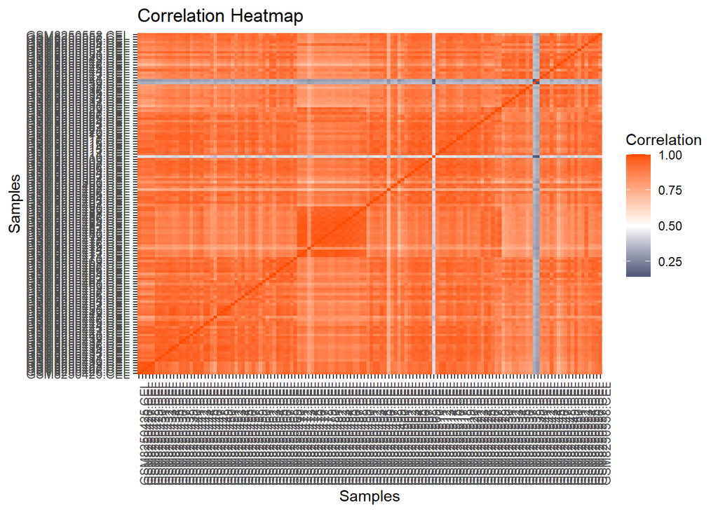

```r
# using ReadAffy() from the affy package would be more concise but it is not applicable for binary cell format
# of the source article...  list and unzip .CEL.gz files
cell_fp <- "gene_data/"
cell_name <- list.files(cell_fp, pattern = "\\.CEL\\.gz$", full.names = TRUE)
cell_file <- gsub("\\.gz$", "", cell_name)
for (i in seq_along(cell_name)) {
    if (!file.exists(cell_file[i])) {
        gunzip(cell_name[i], destname = cell_file[i])
    }
}

# assuming you may have loaded packages other than what are included in this document, you may want to specify
# the oligo package for the read.celfile() function to avoid potential confusions with other packages like
# affyio.
file_list <- list.celfiles(cell_fp, full.names = TRUE)

cell <- oligo::read.celfiles(cell_file)

# initial look at raw data
raw_exp_matrix <- exprs(cell)
corr_matrix <- cor(raw_exp_matrix, method = "pearson")

# make matrix into long format
corr_data <- as.data.frame(as.table(corr_matrix))
colnames(corr_data) <- c("Sample1", "Sample2", "Correlation")

p_heat <- ggplot(corr_data, aes(x = Sample1, y = Sample2, fill = Correlation)) + geom_tile() + scale_fill_gradient2(low = "#041E42",
    high = "#FF4C00", mid = "white", midpoint = 0.5) + theme(axis.text.x = element_text(angle = 90, hjust = 1)) +
    labs(title = "Correlation Heatmap", x = "Samples", y = "Samples", fill = "Correlation")
p_heat
```

| The raw data is highly correlated, which may suppress subsequent analyses. I have a bad feeling about this…

```r
# preprocess raw data for subsequent analyses normalise with Robust Multi-Array Average expression(rma).
cell_norm <- rma(cell)

# modify cell_sample into an annotated dataframe.
pheno_data <- AnnotatedDataFrame(data = cell_sample)

# wrangle the data into an expression data.
exp_set <- ExpressionSet(assayData = exprs(cell_norm), phenoData = pheno_data)
## Background correcting
## Normalizing
## Calculating Expression
```

# 8 Exploratory Data Analysis (EDA)

EDA in this section focus on normality and outlier, which describes the data structure of the source data.

## 8.1 Examination on Normality

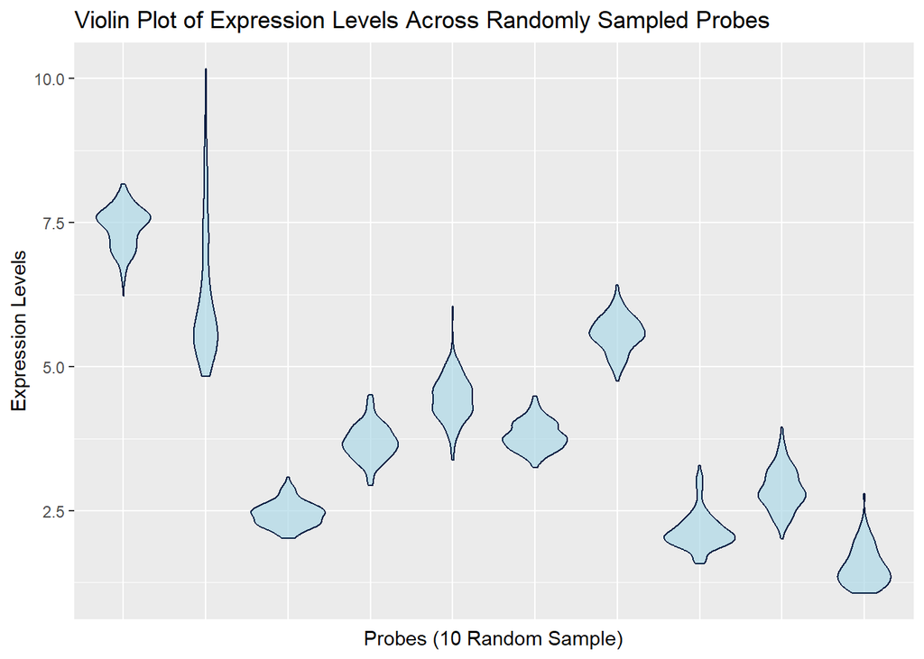

```r
# source data contains too many rows, random down sampling to help visualisation
set.seed(255)
sampled_probe <- sample(1:nrow(exprs(exp_set)), 10)

# create a violin plot for the sample
vio_sample <- exprs(exp_set)[sampled_probe, ]

# transform the wide data into long for violin plot
exp_long <- melt(vio_sample)
colnames(exp_long) <- c("Probe", "Sample", "Expression")

p_vio_sample <- ggplot(exp_long, aes(x = factor(Probe), y = Expression)) + geom_violin(fill = "#ADD8E6", color = "#041E42",
    alpha = 0.7) + labs(title = "Violin Plot of Expression Levels Across Randomly Sampled Probes", x = "Probes (10 Random Sample)",
    y = "Expression Levels") + theme(axis.text.x = element_blank(), axis.ticks.x = element_blank())
p_vio_sample
```

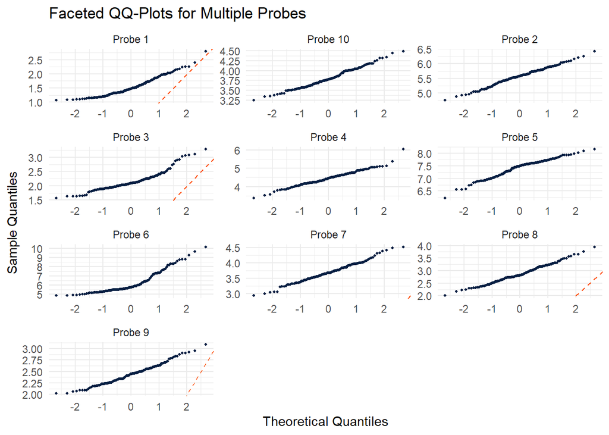

```r
# create a qq plot for the sample
qq_sample <- exprs(exp_set)[sampled_probe, ]

qq_data <- do.call(rbind, lapply(1:nrow(qq_sample), function(i) {
    data.frame(Sample = sort(qq_sample[i, ]), Theoretical = qnorm(ppoints(length(qq_sample[i, ]))), Probe = paste("Probe",
        i))
}))

# add a red dotted line to represent the theoretical normal distribution give the data
p_qq_sample <- ggplot(qq_data, aes(x = Theoretical, y = Sample)) + geom_point(size = 0.7, color = "#041E42") + geom_abline(slope = 1,
    intercept = 0, color = "#FF4C00", linetype = "dashed") + facet_wrap(~Probe, scales = "free", ncol = 3) + labs(title = "Faceted QQ-Plots for Multiple Probes",
    x = "Theoretical Quantiles", y = "Sample Quantiles") + theme_minimal()
p_qq_sample
```

```r
# apply the Shapiro-Wilk test for each probe
shapiro_results <- apply(exprs(exp_set), 1, function(x) shapiro.test(x)$p.value)

# count the number of probes that are not considered, using 0.05 as a cut-off
non_normal_probe_count <- paste("proportion of non-normal probes:", length(shapiro_results[shapiro_results < 0.05])/length(shapiro_results))
print(non_normal_probe_count)
## [1] "proportion of non-normal probes: 0.591849074857903"
```

The 10 samples appear somewhat normal on violin plot, but the QQ-plot shows decent skewness in the data away from a theretical normal distribution. Evaluating all probes in a computational method (i.e. Shapiro-Wilk test) shows over half of the probes are not normally distributed.

## 8.2 Examination on Outliers

```r
# visualise the expression data with a boxplot put intensity data into a dataframe
box_data <- as.data.frame(exprs(exp_set))

# make the data long
box_data$probe <- rownames(box_data)
box_data_long <- melt(box_data, id.vars = "probe", variable.name = "Sample", value.name = "Intensity")

# split the samples into subsets for plotting.
n <- 10
data_chunk <- split(unique(box_data_long$Sample), ceiling(seq_along(unique(box_data_long$Sample))/n))

# plotly container
plot_list <- list()

# make plotly objects for all samples by data_chunk
for (i in seq_along(data_chunk)) {
    subset_data <- box_data_long[box_data_long$Sample %in% data_chunk[[i]], ]

    p_box <- ggplot(subset_data, aes(x = Sample, y = Intensity)) + geom_boxplot(notch = TRUE) + theme(axis.text.x = element_text(angle = 90,
        hjust = 1)) + labs(title = paste("Expression Values by Sample - Set", i), x = "Sample", y = "Expression Intensity")

    plot_list[[i]] <- ggplotly(p_box)
}

# show them in boxplot and see if any major issues from normalisation
for (p in plot_list) {
    print(p)
}
```

```r
outlier_count <- apply(exprs(exp_set), 1, function(x) {
    # r use 1 and 2 instead of 0 and 1
    Q1 <- quantile(x, 0.25)
    Q3 <- quantile(x, 0.75)
    IQR <- Q3 - Q1
    sum(x < (Q1 - 1.5 * IQR) | x > (Q3 + 1.5 * IQR))  # using a 1.5 IQR to balance sensitivity and robusteness
})

outlier_percent <- paste("percentage of outliers across probes:", sum(outlier_count)/(nrow(exprs(exp_set)) * (ncol(exprs(exp_set)))))
print(outlier_percent)
## [1] "percentage of outliers across probes: 0.0178236282609206"
```

## 8.3 Section Conclusion

Given the EDA, we have non-normal data with rare outliers. This confirms that the choice of Mann-Whitney U-test in the source article over Welch’s t-test or Bayesian moderation is justified.

# 9 Differential Gene Expression (DEG)

DEGs in this section look at the expression data from the microarray, and determines which probes from the microarray, if any, are expressed at significantly higher or lower levels. We use the log-fold changes as a measure. Note that for small dataset, or dataset with many outliers empirical Bayes moderation may perform better.

## 9.1 Setting up Pairwise Comparison of any Two Groups

```r
two_grp_degs <- function(group_1, group_2) {
    # Convert input to character.
    grp_1 <- as.character(group_1)
    grp_2 <- as.character(group_2)

    # get the phenodata.
    pheno <- pData(exp_set)[pData(exp_set)$Ex_group %in% c(grp_1, grp_2), ]
    exp_subset <- exprs(exp_set)[, rownames(pheno)]

    probe_results <- data.frame(Probe = rownames(exp_subset), p.value = NA, W = NA)

    # Mann-Whitney U-test and cliff delta for each probe
    for (i in 1:nrow(exp_subset)) {
        probe_values <- exp_subset[i, ]
        group_1_values <- probe_values[pheno$Ex_group == grp_1]
        group_2_values <- probe_values[pheno$Ex_group == grp_2]

        # Mann-Whitney
        test_result <- wilcox.test(group_1_values, group_2_values, exact = FALSE)
        probe_results$p.value[i] <- test_result$p.value
        probe_results$W[i] <- test_result$statistic

        # Cliff delta
        cliff_delta_result <- cliff.delta(group_1_values, group_2_values)
        probe_results$CliffDelta[i] <- cliff_delta_result$estimate
    }

    # sort probes by p-value
    probe_results <- probe_results[order(probe_results$p.value), ]

    # Make a volcano plot to see how many probes are differentially expressed and whether they are up or down
    # regulated
    p_title <- paste0(toupper(substring(grp_1, 1, 1)), tolower(substring(grp_1, 2)), "  VS  ", toupper(substring(grp_2,
        1, 1)), tolower(substring(grp_2, 2)))
    # we do not have significant number of outliers, mean instead of median is used here
    probe_results$logFC <- apply(exp_subset, 1, function(x) mean(x[pheno$Ex_group == grp_2]) - mean(x[pheno$Ex_group ==
        grp_1]))
    probe_results$adj.P.Val <- p.adjust(probe_results$p.value, method = "BH")
    x <- probe_results$logFC
    y <- -log2(probe_results$adj.P.Val)
    p <- ggplot(probe_results, aes(x, y)) + geom_point() + labs(x = "LogFC", y = "Negative log2 adjusted p-value",
        title = p_title) + geom_hline(yintercept = -log2(0.05), linetype = "dashed", color = "#FF4C00") + geom_hline(yintercept = -log2(0.01),
        linetype = "dashed", color = "#ADD8E6") + theme_minimal()

    # Put results together in a list
    result <- list(probe_results, p)
    names(result) <- c("deg_results", "plot")

    # Return the data as list for subsequent cbind
    return(result)
}
```

## 9.2 Uninfected vs Asymtomatic Controller

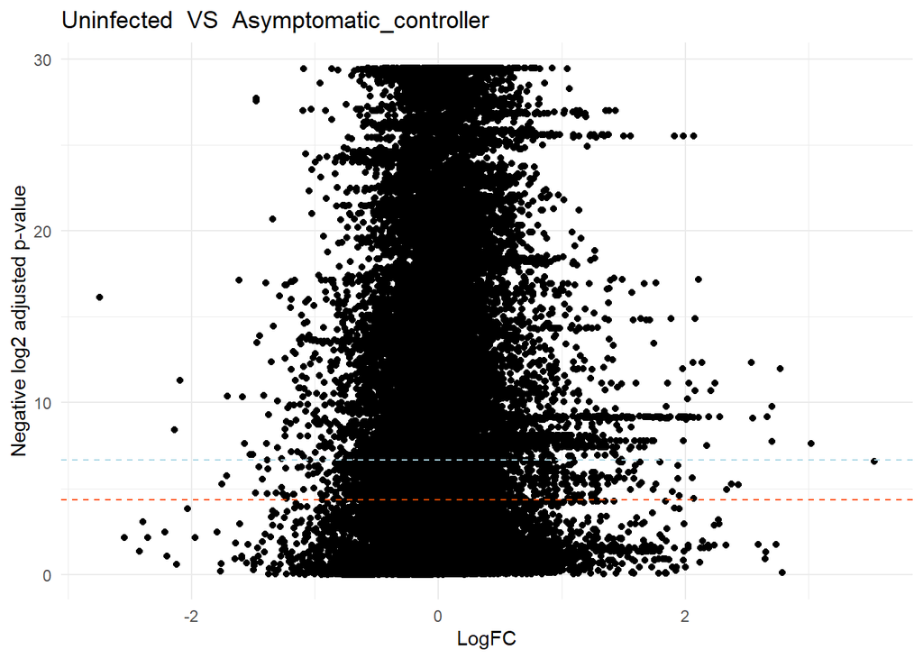

```
##          Probe      p.value    W CliffDelta       logFC    adj.P.Val
## 6016  17218765 1.360091e-12 1325  1.0000000  0.20224742 1.309057e-09
## 17764 17332851 1.360091e-12 1325  1.0000000  0.26379304 1.309057e-09
## 25658 17411174 1.360091e-12 1325  1.0000000  0.14519325 1.309057e-09
## 29096 17447737 1.360091e-12 1325  1.0000000  0.22758392 1.309057e-09
## 13200 17289304 1.469384e-12 1324  0.9984906 -0.37196119 1.309057e-09
## 29696 17453205 1.469384e-12 1324  0.9984906 -0.01942914 1.309057e-09
```

```r
# note that this section contains many probes that are fully disjoint between the chosen two groups, the
# warning messages are not printed to avoid clutter. The total disjoint is likely related to the uneven sample
# size in the source data, which may be accommodated by downsamping if needed.
g <- c("uninfected", "asymptomatic_controller")
deg_ui_ac <- two_grp_degs(g[1], g[2])
head(deg_ui_ac$deg_results)
deg_ui_ac$plot
```

For each probe (i.e. first column in deg_result table),

(1) logFC is the full changes between treatment times.  
(2) CliffDelta is estimation on the effect size.  
(3) W is the U-test statistic value.  
(4) p.value is the p-value.  
(5) adj.P.Value is the adjusted p-value for multiple testing across all probes.

## 9.3 Uninfected vs Chronic Controller

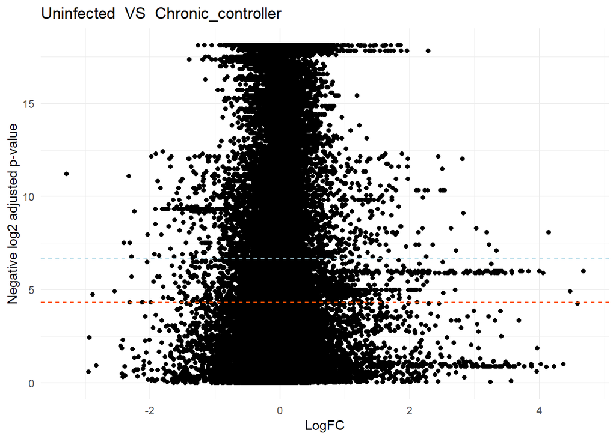

```
##         Probe      p.value   W CliffDelta       logFC    adj.P.Val
## 1131 17202293 5.557753e-08   0         -1  0.22990840 3.491952e-06
## 1167 17202365 5.557753e-08   0         -1  0.48685135 3.491952e-06
## 1170 17202371 5.557753e-08   0         -1  0.06416638 3.491952e-06
## 5481 17212442 5.557753e-08 425          1  0.33550636 3.491952e-06
## 5494 17212724 5.557753e-08   0         -1 -0.04490572 3.491952e-06
## 5545 17213369 5.557753e-08 425          1  0.14203227 3.491952e-06
```

```r
g <- c("uninfected", "chronic_controller")
deg_ui_cc <- two_grp_degs(g[1], g[2])
head(deg_ui_cc$deg_results)
deg_ui_cc$plot
```

## 9.4 Uninfected vs Progressor

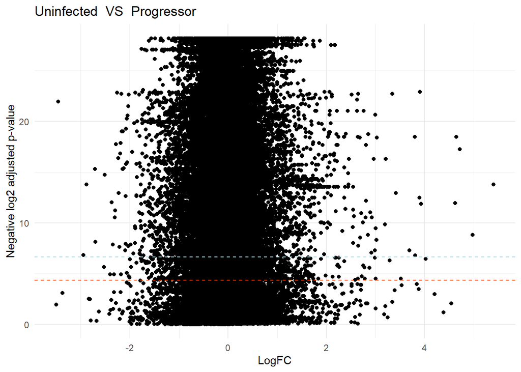

```
##          Probe      p.value   W CliffDelta       logFC    adj.P.Val
## 14511 17300349 2.064315e-11 975          1  0.34374754 3.248298e-09
## 6728  17225929 2.065399e-11 975          1  0.13654667 3.248298e-09
## 7147  17230735 2.065399e-11 975          1  0.08530978 3.248298e-09
## 7437  17233408 2.065399e-11 975          1  0.30454773 3.248298e-09
## 7458  17233635 2.065399e-11   0         -1 -0.41925446 3.248298e-09
## 7540  17234317 2.065399e-11 975          1  0.02816917 3.248298e-09
```

```r
g <- c("uninfected", "progressor")
deg_ui_pr <- two_grp_degs(g[1], g[2])
head(deg_ui_pr$deg_results)
deg_ui_pr$plot
```

## 9.5 Asymtomatic Controller vs Chronic Controller

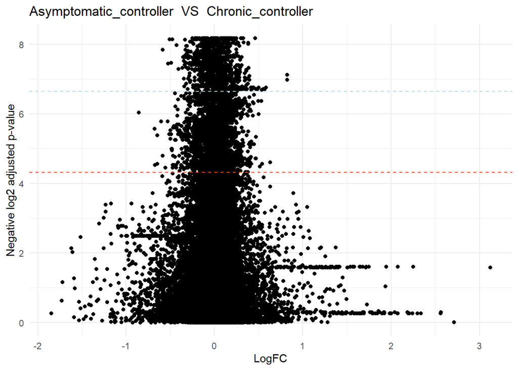

```
##          Probe      p.value   W CliffDelta       logFC   adj.P.Val
## 10133 17260236 3.244337e-07 824  0.8290788  0.02766098 0.003447869
## 38778 17540027 3.487887e-07  78 -0.8268590  0.22305830 0.003447869
## 23481 17389510 4.995296e-07 818  0.8157603 -0.08102687 0.003447869
## 31104 17466805 8.196895e-07 811  0.8002220  0.10792245 0.003447869
## 37939 17533093 8.196895e-07 811  0.8002220  0.32705546 0.003447869
## 13789 17294086 1.083488e-06 807  0.7913430  0.16146140 0.003447869
```

```r
g <- c("asymptomatic_controller", "chronic_controller")
deg_ac_cc <- two_grp_degs(g[1], g[2])
head(deg_ac_cc$deg_results)
deg_ac_cc$plot
```

## 9.6 Asymtomatic Controller vs Progressor

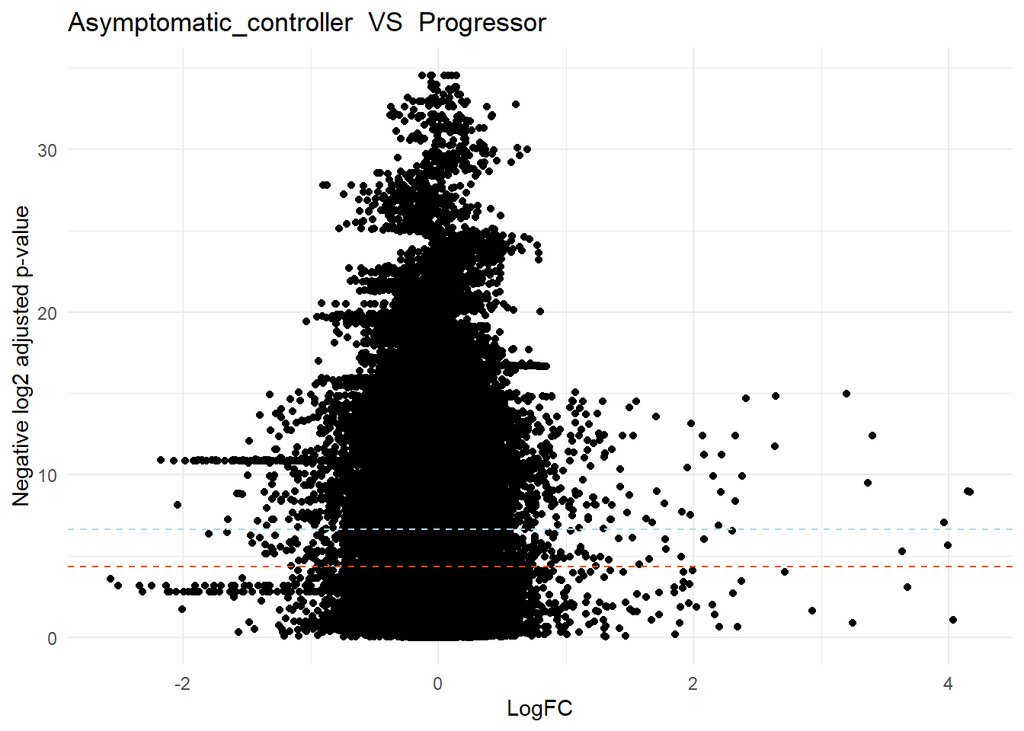

```
##          Probe      p.value  W CliffDelta       logFC    adj.P.Val
## 17041 17326075 2.014533e-15 28 -0.9729076  0.14150012 3.913795e-11
## 35119 17503942 2.768020e-15 33 -0.9680697 -0.12724637 3.913795e-11
## 36933 17522369 3.141811e-15 35 -0.9661345 -0.05988347 3.913795e-11
## 25279 17407363 3.797485e-15 38 -0.9632317  0.07696381 3.913795e-11
## 20828 17362874 5.201820e-15 43 -0.9583938 -0.04729327 3.913795e-11
## 14703 17302279 7.114540e-15 48 -0.9535559  0.04759830 3.913795e-11
```

```r
g <- c("asymptomatic_controller", "progressor")
deg_ac_pr <- two_grp_degs(g[1], g[2])
head(deg_ac_pr$deg_results)
deg_ac_pr$plot
```

## 9.7 Chronic Controller vs Progressor

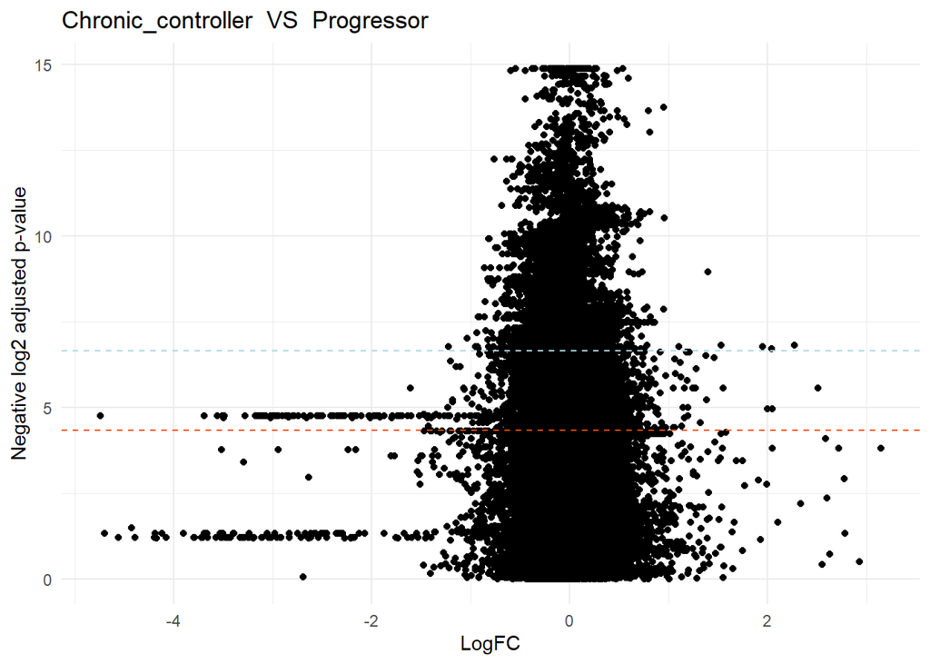

```
##          Probe      p.value   W CliffDelta       logFC    adj.P.Val
## 31248 17467522 6.278359e-09 658  0.9849170  0.11383913 3.294879e-05
## 12604 17284517 8.627806e-09 655  0.9758673 -0.35030468 3.294879e-05
## 12557 17284387 1.064792e-08 653  0.9698341  0.02114340 3.294879e-05
## 15490 17309644 1.064792e-08 653  0.9698341 -0.03095864 3.294879e-05
## 12620 17284562 1.182348e-08 652  0.9668175 -0.37434874 3.294879e-05
## 12638 17284612 1.182348e-08 652  0.9668175 -0.11386310 3.294879e-05
```

```r
g <- c("chronic_controller", "progressor")
deg_cc_pr <- two_grp_degs(g[1], g[2])
head(deg_cc_pr$deg_results)
deg_cc_pr$plot
```